# Assignment 8

**Student Name:** Eliza Tsang **Student ID:** 999606858

## Assignment 8: Gene Networks 2

```r
cities <- read.table("../Assignment_8_Tsang.Eliza/us_cities.txt", sep = "\t", header = TRUE)
rownames(cities) <- cities$X #make first column the rownames
cities <- cities[,-1] #remove first column
cities <- as.matrix(cities) #convert to matrix
cities
```

```
##       BOS   NY   DC  MIA  CHI  SEA   SF   LA  DEN
## BOS     0  206  429 1504  963 2976 3095 2979 1949
## NY    206    0  233 1308  802 2815 2934 2786 1771
## DC    429  233    0 1075  671 2684 2799 2631 1616
## MIA  1504 1308 1075    0 1329 3273 3053 2687 2037
## CHI   963  802  671 1329    0 2013 2142 2054  996
## SEA  2976 2815 2684 3273 2013    0  808 1131 1307
## SF   3095 2934 2799 3053 2142  808    0  379 1235
## LA   2979 2786 2631 2687 2054 1131  379    0 1059
## DEN  1949 1771 1616 2037  996 1307 1235 1059    0
```

*Cities with distances greater than 1500 miles between them would no longer be reachable directly. Their edge value would become a zero. Likewise, if two cities are within 1500 miles, their edge value would become 1. This 1 or 0 representation of the network is called the network adjacency matrix.*

```r
cities_mat <- cities < 1500 # leave original matrix intact
diag(cities_mat) <- 0 # do not have to fly within each of cities
cities_mat # check out adjacency matrix
```

```
##      BOS NY DC MIA CHI SEA SF LA DEN
## BOS    0  1  1   0   1   0  0  0   0
## NY     1  0  1   1   1   0  0  0   0
## DC     1  1  0   1   1   0  0  0   0
## MIA    0  1  1   0   1   0  0  0   0
## CHI    1  1  1   1   0   0  0  0   1
## SEA    0  0  0   0   0   0  1  1   1
## SF     0  0  0   0   0   1  0  1   1
## LA     0  0  0   0   0   1  1  0   1
## DEN    0  0  0   0   1   1  1  1   0
```

```
|BOS| 3|
|NY|4|
|DC|4|
|MIA|3|
|CHI|5|
|SEA|3|
|SF|3|
|LA|3|
|DEN|4|
```

**Exercise 1:**

**Based on this 0 or 1 representation of our network, what city is the most highly connected?** *Hint: sum the values down a column OR across a row for each city*

Chicago has a total value of 5, making it the most highly connected based on this representation.

**What if you were to extend the range to 2000 miles in the above code. Does the highest connected city change? If so explain.**

```r
cities_mat2 <- cities < 2000
diag(cities_mat2) <- 0
cities_mat2
```

```
##      BOS NY DC MIA CHI SEA SF LA DEN
## BOS    0  1  1   1   1   0  0  0   1
## NY     1  0  1   1   1   0  0  0   1
## DC     1  1  0   1   1   0  0  0   1
## MIA    1  1  1   0   1   0  0  0   0
## CHI    1  1  1   1   0   0  0  0   1
## SEA    0  0  0   0   0   0  1  1   1
## SF     0  0  0   0   0   1  0  1   1
## LA     0  0  0   0   0   1  1  0   1
## DEN    1  1  1   0   1   1  1  1   0
```

```
|BOS| 5|
|NY|5|
|DC|5|
|MIA|4|
|CHI|5|
|SEA|3|
|SF|3|
|LA|3|
|DEN|7|
```

Yes, now Denver has the most connections with 7. (Also, BOS, NY, DC, and MIA have also increased in the number of connections) Denver, which had places over 1500 miles away, have many within 2000 miles. Because the maximum mileage has been increased to 2000, Denver became the most connected city based on these guidelines. (It also affected other cities as more connections were available there too.)

**Exercise 2:**

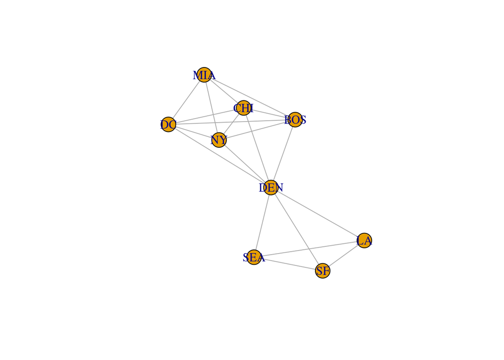

```r
library(igraph)
cities_graph2 <- graph.adjacency(cities_mat2, mode = "undirected")
plot.igraph(cities_graph2)
```

```r
sum(cities_mat2)/2 # divide by 2 because the matrix has 2 values for each edge
```

```
## [1] 20
```

**What is the total number of nodes in the plot?** 9 **What is the total number of edges in the plot?** 20

**Exercise 3:** **Re-calculate the adjacency matrix with the cutoff value at 2300. Calculate the number of edges using the following code. What do you get?**

```r
cities_mat3 <- cities < 2300
diag(cities_mat3) <- 0
cities_mat3
```

```
##      BOS NY DC MIA CHI SEA SF LA DEN
## BOS    0  1  1   1   1   0  0  0   1
## NY     1  0  1   1   1   0  0  0   1
## DC     1  1  0   1   1   0  0  0   1
## MIA    1  1  1   0   1   0  0  0   1
## CHI    1  1  1   1   0   1  1  1   1
## SEA    0  0  0   0   1   0  1  1   1
## SF     0  0  0   0   1   1  0  1   1
## LA     0  0  0   0   1   1  1  0   1
## DEN    1  1  1   1   1   1  1  1   0
```

```r
sum(cities_mat3)/2 # divide by 2 because the matrix has 2 values for each edge
```

```
## [1] 24
```

It calculated 24 edges.

**Exercise 4:**

**(Gene1)–(+0.9)–(Gene2)**

**(Gene2)–(-0.76)–(Gene3)**

**(Gene1)–(+0.50)–(Gene3)**

**(Gene3)–(-0.69)–(Gene4)**

**Fill in the following 0 or 1 values for our gene network above.**

(Gene1)–(1)–(Gene2)

(Gene2)–(1)–(Gene3)

(Gene1)–(0)–(Gene3)

(Gene3)–(0)–(Gene4)

**Exercise 5:**

```r
genes <- read.table("voom_transform_brassica.csv", sep = ",", header = TRUE)
genes <- genes[,-c(38,42,46)] # remove questionable library columns
DE_genes <- read.table("DEgenes_GxE.csv", sep = ",")
DE_gene_names <- rownames(DE_genes)
GxE_counts <- as.data.frame(genes[DE_gene_names,])
genes_cor <- cor(t(GxE_counts)) # calculate the correlation between all gene pairs
```

**a) Create an adjacency matrix called `genes_adj85` for the genes use a cutoff of abs(correlation) > 0.85. Remember to set the diagonal of the adjacency matrix to 0. Create a second adjacency matrix `genes_adj95` using a cutoff of abs(correlation) > 0.95. See above code for cities.**

```r
genes_adj85 <- abs(genes_cor) > 0.85
diag(genes_adj85) <- 0
head(genes_adj85)
```

```
##           Bra010821 Bra033034 Bra035334 Bra003598 Bra016182 Bra013164
## Bra010821         0         0         0         0         0         0
## Bra033034         0         0         0         0         0         0
## Bra035334         0         0         0         0         0         0
## Bra003598         0         0         0         0         0         0
## Bra016182         0         0         0         0         0         0
## Bra013164         0         0         0         0         0         0
##           Bra009406 Bra033856 Bra011196 Bra041036 Bra011170 Bra037664
## Bra010821         0         0         0         0         0         0
## Bra033034         0         0         0         0         0         0
## Bra035334         0         0         0         0         0         0
## Bra003598         0         0         0         0         0         0
## Bra016182         0         0         0         0         0         0
## Bra013164         0         0         0         0         0         0
##           Bra002697 Bra025547 Bra016316 Bra019741 Bra020500 Bra005176
## Bra010821         0         0         0         0         0         0
## Bra033034         0         0         0         0         0         0
## Bra035334         0         0         0         0         0         0
## Bra003598         0         0         0         0         0         0
## Bra016182         0         0         0         0         0         0
## Bra013164         0         0         0         0         1         1
##           Bra036334 Bra013340 Bra011670 Bra038908 Bra027181 Bra018722
## Bra010821         0         0         0         0         0         0
## Bra033034         0         0         0         0         0         0
## Bra035334         0         0         0         0         0         0
## Bra003598         0         0         0         0         0         0
## Bra016182         0         0         0         0         0         0
## Bra013164         1         0         0         0         1         1
##           Bra002896 Bra010292 Bra021913 Bra011195
## Bra010821         0         0         0         0
## Bra033034         0         0         0         0
## Bra035334         0         0         0         0
## Bra003598         0         0         0         0
## Bra016182         0         0         0         0
## Bra013164         0         0         0         0
##           Bra007907_Bra007908_Bra007909 Bra027700 Bra036607 Bra002515
## Bra010821                             0         0         0         0
## Bra033034                             0         0         0         0
## Bra035334                             0         0         0         0
## Bra003598                             0         0         0         0
```

[output cut: 253 more lines]

```
## Bra013164         0         0         0         1         0         0
##           Bra034140 Bra000534 Bra012597 Bra028400 Bra030116 Bra004581
## Bra010821         0         0         0         0         0         0
## Bra033034         0         0         0         0         0         0
## Bra035334         0         0         0         0         0         0
## Bra003598         0         0         0         0         0         0
## Bra016182         0         0         0         0         0         0
## Bra013164         0         0         0         0         0         0
##           Bra009182 Bra101149 Bra027206 Bra006173
## Bra010821         0         0         0         0
## Bra033034         0         0         0         0
## Bra035334         0         0         0         0
## Bra003598         0         0         0         0
## Bra016182         0         0         0         0
## Bra013164         0         0         0         0
```

```r
genes_adj95 <- abs(genes_cor) > 0.95
diag(genes_adj95) <- 0
head(genes_adj95)
```

```
##           Bra010821 Bra033034 Bra035334 Bra003598 Bra016182 Bra013164
## Bra010821         0         0         0         0         0         0
## Bra033034         0         0         0         0         0         0
## Bra035334         0         0         0         0         0         0
## Bra003598         0         0         0         0         0         0
## Bra016182         0         0         0         0         0         0
## Bra013164         0         0         0         0         0         0
##           Bra009406 Bra033856 Bra011196 Bra041036 Bra011170 Bra037664
## Bra010821         0         0         0         0         0         0
## Bra033034         0         0         0         0         0         0
## Bra035334         0         0         0         0         0         0
## Bra003598         0         0         0         0         0         0
## Bra016182         0         0         0         0         0         0
## Bra013164         0         0         0         0         0         0
##           Bra002697 Bra025547 Bra016316 Bra019741 Bra020500 Bra005176
## Bra010821         0         0         0         0         0         0
## Bra033034         0         0         0         0         0         0
## Bra035334         0         0         0         0         0         0
## Bra003598         0         0         0         0         0         0
## Bra016182         0         0         0         0         0         0
## Bra013164         0         0         0         0         0         0
##           Bra036334 Bra013340 Bra011670 Bra038908 Bra027181 Bra018722
## Bra010821         0         0         0         0         0         0
## Bra033034         0         0         0         0         0         0
## Bra035334         0         0         0         0         0         0
## Bra003598         0         0         0         0         0         0
## Bra016182         0         0         0         0         0         0
## Bra013164         0         0         0         0         0         0
##           Bra002896 Bra010292 Bra021913 Bra011195
## Bra010821         0         0         0         0
## Bra033034         0         0         0         0
## Bra035334         0         0         0         0
## Bra003598         0         0         0         0
## Bra016182         0         0         0         0
## Bra013164         0         0         0         0
##           Bra007907_Bra007908_Bra007909 Bra027700 Bra036607 Bra002515
## Bra010821                             0         0         0         0
## Bra033034                             0         0         0         0
## Bra035334                             0         0         0         0
## Bra003598                             0         0         0         0
```

[output cut: 253 more lines]

```
## Bra013164         0         0         0         0         0         0
##           Bra034140 Bra000534 Bra012597 Bra028400 Bra030116 Bra004581
## Bra010821         0         0         0         0         0         0
## Bra033034         0         0         0         0         0         0
## Bra035334         0         0         0         0         0         0
## Bra003598         0         0         0         0         0         0
## Bra016182         0         0         0         0         0         0
## Bra013164         0         0         0         0         0         0
##           Bra009182 Bra101149 Bra027206 Bra006173
## Bra010821         0         0         0         0
## Bra033034         0         0         0         0
## Bra035334         0         0         0         0
## Bra003598         0         0         0         0
## Bra016182         0         0         0         0
## Bra013164         0         0         0         0
```

**b) Now we can do some calculations. If our cutoff is 0.85, how many edges do we have in our 255 node network? What if we increase our cutoff to 0.95?**

```r
sum(genes_adj85)/2
```

```
## [1] 525
```

```r
sum(genes_adj95)/2
```

```
## [1] 9
```

At 0.85 cutoff, we have 525 edges. At 0.95 cutoff, we have 9 edges.

Our cutoff was stricter at 0.95 (the correlation had to have an absolute value of 0.95 or above), so there are fewer edges considered.

**Exercise 6:** **Use the following code to plot our networks using different thresholds for connectivity. What patterns do you see in the visualization of this data?** *Note: the second plot will take a while to render*

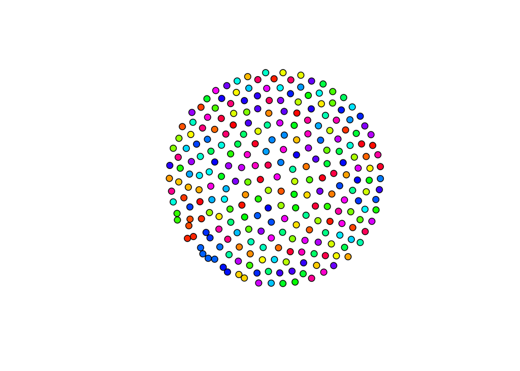

```r
gene_graph95 <- graph.adjacency(genes_adj95, mode = "undirected") #convert adjacency to graph
comps <- clusters(gene_graph95)$membership                        #define gene cluster membership
colbar <- rainbow(max(comps)+1)                                   #define colors
V(gene_graph95)$color <- colbar[comps+1]                          #assign colors to nodes
plot(gene_graph95, layout = layout.fruchterman.reingold, vertex.size = 6, vertex.label = NA)
```

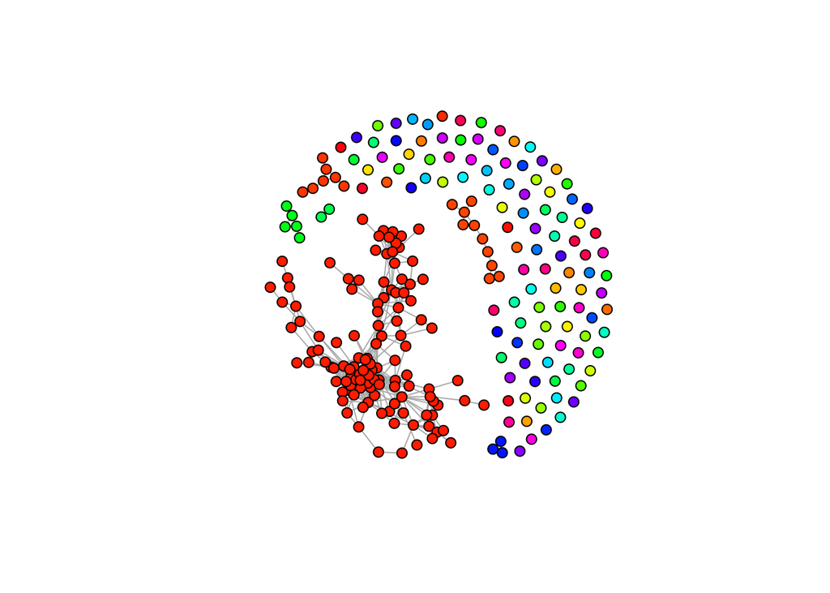

```r
#this one will take a little while to render
gene_graph85 <- graph.adjacency(genes_adj85, mode = "undirected")
comps <- clusters(gene_graph85)$membership
colbar <- rainbow(max(comps)+1)
V(gene_graph85)$color <- colbar[comps+1]
plot(gene_graph85, layout=layout.fruchterman.reingold, vertex.size=6, vertex.label=NA)
```

For 0.85, the red nodes are more grouped together with many edges between them. For the 0.95 chart, there doesn’t seem to be a visible pattern (save for a few blue dots in the lower left quadrant, those may be the nodes with the 9 edges); all the nodes seem to be more or less evenly distributed.

**Exercise 7:** Use the following code to answer these two questions: In gene_graph85, what is the total graph density? In gene_graph85, what is the average path length?

```r
graph.density(gene_graph85)
```

```
## [1] 0.01621121
```

```r
average.path.length(gene_graph85)
```

```
## [1] 3.663435
```

The density of gene_graph85 is 0.01621121, and the average path length is 3.663435.

```r
gene_graph85 <- graph.adjacency(genes_adj85, mode = "undirected")
distMatrix <- shortest.paths(gene_graph85, v = V(gene_graph85), to = V(gene_graph85))
head(distMatrix)[,1:7]
```

```
##           Bra010821 Bra033034 Bra035334 Bra003598 Bra016182 Bra013164
## Bra010821         0       Inf       Inf       Inf       Inf       Inf
## Bra033034       Inf         0       Inf       Inf       Inf         4
## Bra035334       Inf       Inf         0       Inf       Inf       Inf
## Bra003598       Inf       Inf       Inf         0       Inf       Inf
## Bra016182       Inf       Inf       Inf       Inf         0       Inf
## Bra013164       Inf         4       Inf       Inf       Inf         0
##           Bra009406
## Bra010821       Inf
## Bra033034         6
## Bra035334       Inf
## Bra003598       Inf
## Bra016182       Inf
## Bra013164         3
```

*We are interested in visualizing the path between Bra033034 (row number 2) and Bra009406 (column number 7). This is where the 2 and 7 arguments come from in get.shortest.paths()*

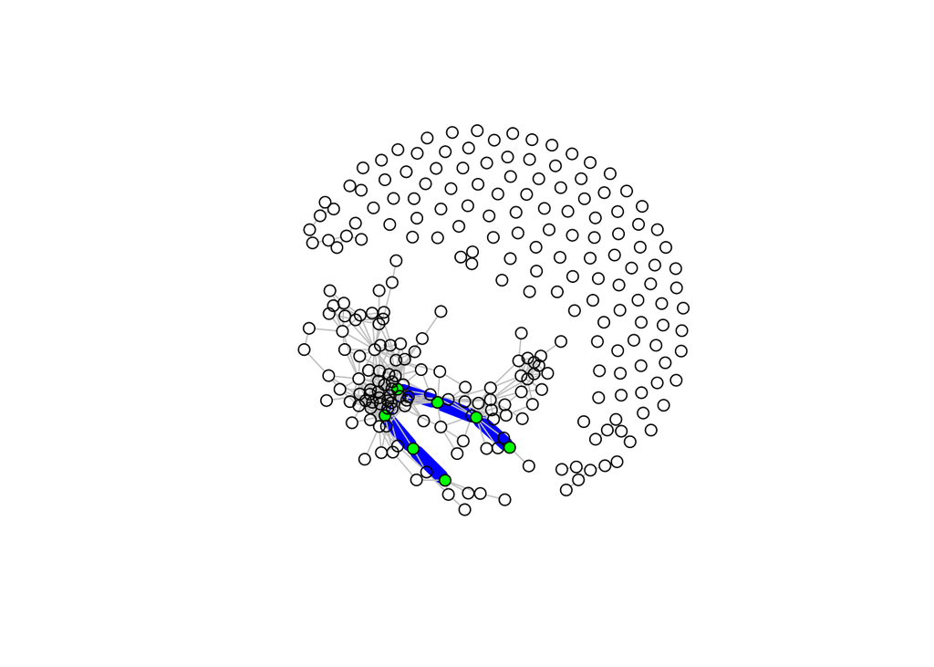

```r
pl <- get.shortest.paths(gene_graph85, 2, 7)$vpath[[1]] # pull paths between node 2 and 7

V(gene_graph85)[pl]$color <- paste("green")          # define node color
E(gene_graph85)$color <- paste("grey")               # define default edge color
E(gene_graph85, path = pl)$color <- paste("blue")    # define edge color
E(gene_graph85, path = pl)$width <- 10               # define edge width
plot(gene_graph85, layout = layout.fruchterman.reingold, vertex.size = 6, vertex.label = NA)
```

**Exercise 8: Using what you know about graphs, repeat your analysis of the smaller cities matrix. Show your code to answer these questions.**

**What is the graph density of the cities network with a 1500 mile flight range? What is the average path length of the cities network with a 1500 mile flight range?**

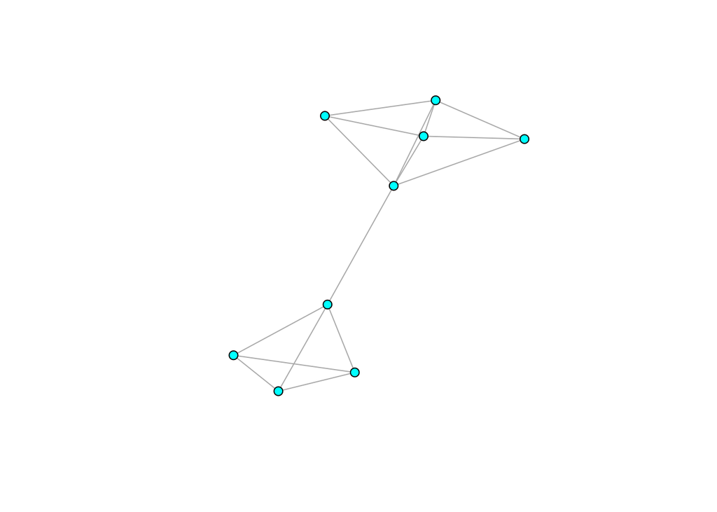

```r
cities_mat1500 <- graph.adjacency(cities_mat, mode = "undirected")
comps <- clusters(cities_mat1500)$membership
colbar <- rainbow(max(comps)+1)
V(cities_mat1500)$color <- colbar[comps+1]
plot(cities_mat1500, layout=layout.fruchterman.reingold, vertex.size=6, vertex.label=NA)
```

```r
graph.density(cities_mat1500)
```

```
## [1] 0.4444444
```

```r
average.path.length(cities_mat1500)
```

```
## [1] 1.888889
```

The graph density of the 1500 mile flight range is 0.4444444 and the average path length is 1.888889.

**Find the shortest path between SEA and DC with 1500 mile flight range. Graph it.**

```r
head(cities_mat)
```

```
##      BOS NY DC MIA CHI SEA SF LA DEN
## BOS    0  1  1   0   1   0  0  0   0
## NY     1  0  1   1   1   0  0  0   0
## DC     1  1  0   1   1   0  0  0   0
## MIA    0  1  1   0   1   0  0  0   0
## CHI    1  1  1   1   0   0  0  0   1
## SEA    0  0  0   0   0   0  1  1   1
```

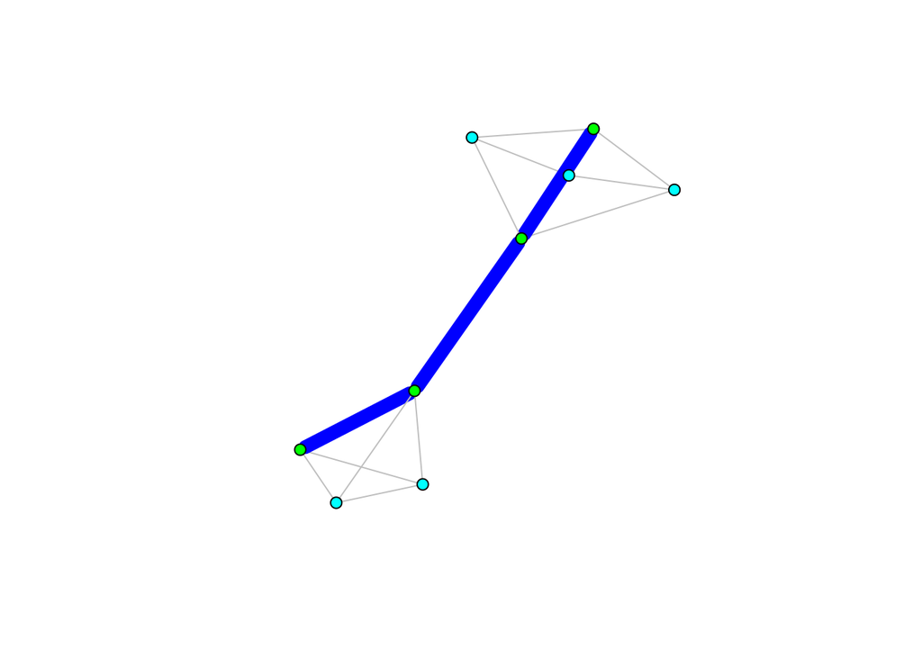

```r
SEA_DC_1500 <- get.shortest.paths(cities_mat1500, 3,6 )$vpath[[1]]

V(cities_mat1500)[SEA_DC_1500]$color <- paste("green")          # define node color
E(cities_mat1500)$color <- paste("grey")               # define default edge color
E(cities_mat1500, path = SEA_DC_1500)$color <- paste("blue")    # define edge color
E(cities_mat1500, path = SEA_DC_1500)$width <- 10               # define edge width
plot(cities_mat1500, layout = layout.fruchterman.reingold, vertex.size = 6, vertex.label = NA)
```

The shortest path is across 4 nodes and 3 edges.

**Find the shortest path between SEA and DC with 2300 mile flight range. Graph it.**

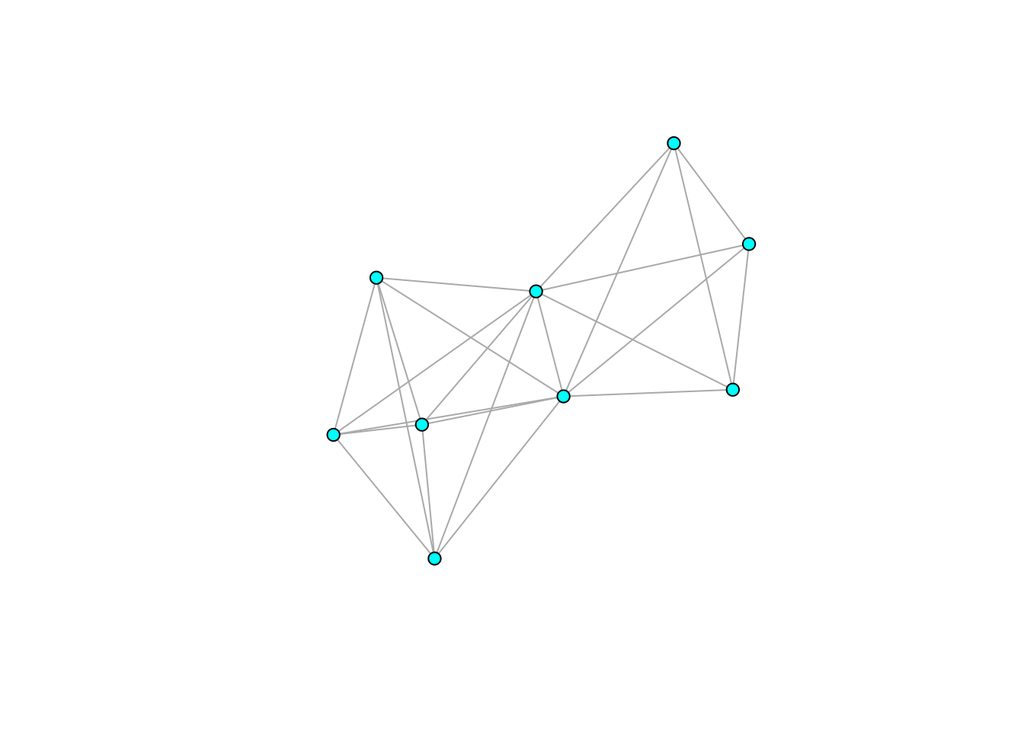

```r
cities_mat2300 <- graph.adjacency(cities_mat3, mode = "undirected")
comps <- clusters(cities_mat2300)$membership
colbar <- rainbow(max(comps)+1)
V(cities_mat2300)$color <- colbar[comps+1]
plot(cities_mat2300, layout=layout.fruchterman.reingold, vertex.size=6, vertex.label=NA)
```

```r
head(cities_mat3)
```

```
##      BOS NY DC MIA CHI SEA SF LA DEN
## BOS    0  1  1   1   1   0  0  0   1
## NY     1  0  1   1   1   0  0  0   1
## DC     1  1  0   1   1   0  0  0   1
## MIA    1  1  1   0   1   0  0  0   1
## CHI    1  1  1   1   0   1  1  1   1
## SEA    0  0  0   0   1   0  1  1   1
```

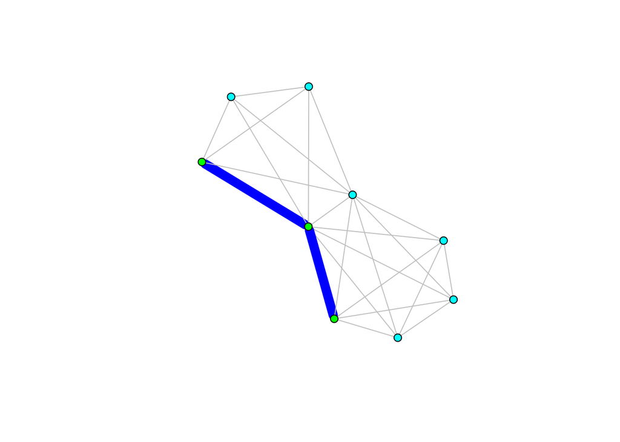

```r
SEA_DC_2300 <- get.shortest.paths(cities_mat2300, 3, 6)$vpath[[1]]

V(cities_mat2300)[SEA_DC_2300]$color <- paste("green")
E(cities_mat2300)$color <- paste("grey")
E(cities_mat2300, path = SEA_DC_2300)$color <- paste("blue")
E(cities_mat2300, path = SEA_DC_2300)$width <- 10
plot(cities_mat2300, layout = layout.fruchterman.reingold, vertex.size = 6, vertex.label = NA)
```

Since the 2300 mile threshold is greater than 1500, there are fewer nodes and edges needed to find the shortest path.